# HW3 Peer Assessment

Sun Mar 17 22:05:13 2024 EDT

# Part 1: Logistic Regression

# Background

The objective is to predict whether a passenger survived the Titanic disaster

## Data Description

1. **Survival**: (1 if the passenger survived, 0 if they did not).
2. **Pclass**: Numeric (1,2,3).
3. **Sex**: Categorical (male, female)
4. **Age**: Numeric.
5. **SibSp**: Number of siblings/spouses aboard.
6. **Parch**: Number of parents/children aboard.
7. **Fare**：Numeric.

## Setup

You can import the data and set up the problem with the following R code:

```r
# Import the data
rawdata = read.csv("data/Titanic.csv", header=TRUE)

# Remove columns that we do not want
rawdata$X <- NULL
rawdata$PassengerId <- NULL
rawdata$Name <- NULL
rawdata$Ticket <- NULL
rawdata$Cabin <- NULL

# Set variables as categorical
rawdata$Pclass<-as.factor(rawdata$Pclass)
rawdata$Sex<-as.factor(rawdata$Sex)
rawdata$SibSp<-as.factor(rawdata$SibSp)
rawdata$Parch<-as.factor(rawdata$Parch)

# Print head of rawdata
head(rawdata)
```

|  | Survived | Pclass | Sex | Age | SibSp | Parch | Fare |
| --- | --- | --- | --- | --- | --- | --- | --- |
| 1 | 0 | 3 | male | 22 | 1 | 0 | 7.2500 |
| 2 | 1 | 1 | female | 38 | 1 | 0 | 71.2833 |
| 3 | 1 | 3 | female | 26 | 0 | 0 | 7.9250 |
| 4 | 1 | 1 | female | 35 | 1 | 0 | 53.1000 |
| 5 | 0 | 3 | male | 35 | 0 | 0 | 8.0500 |
| 6 | 0 | 3 | male | NA | 0 | 0 | 8.4583 |

**Note:** For all of the following questions, treat variables **Age** and **Fare** as quantitative variables and **Pclass**, **Sex**, **SibSp**,and **Parch** as categorical variables. Categorical variables have already been converted to factors in the starter code.

# Question 1: Fitting the Model - 9 pts

Use *Survived* as the response variable to fit a logistic regression model using logit as the link function with *Pclass* as the predictor. Call it **model1**.

**(a) 3 pts - Print the model1 summary table. What are the model parameters and estimates?**

```r
model1 <- glm(Survived ~ Pclass, data = rawdata, family = "binomial")
summary(model1)
```

```
##
## Call:
## glm(formula = Survived ~ Pclass, family = "binomial", data = rawdata)
##
## Coefficients:
##             Estimate Std. Error z value Pr(>|z|)
## (Intercept)   0.5432     0.1415   3.840 0.000123 ***
## Pclass2      -0.6520     0.2045  -3.189 0.001430 **
## Pclass3      -1.6390     0.1767  -9.276  < 2e-16 ***
## ---
## Signif. codes:  0 '***' 0.001 '**' 0.01 '*' 0.05 '.' 0.1 ' ' 1
##
## (Dispersion parameter for binomial family taken to be 1)
##
##     Null deviance: 1170.0  on 873  degrees of freedom
## Residual deviance: 1072.1  on 871  degrees of freedom
## AIC: 1078.1
##
## Number of Fisher Scoring iterations: 4
```

- **Pclass1** (Intercept): 0.5432. This represents the log odds of survival for passengers in Pclass1.
- **Pclass2**: -0.6520. This represents the decreased log odds of survival compared to being in Pclass1, holding all else constant.
- **Pclass3**: -1.6390. This represents the decreased log odds of survival compared to being in Pclass1, holding all else constant.

**(b) 6 pts - Calculate the odds ratio and interpret the estimated coefficient of *Pclass2* with respect to the log-odds of survival and the odds of survival.**

```r
paste0("The odds-log of survival for being in Pclass2 is -0.6520, which translates to a ", exp(-0.6520) %>% round(3)*100, "% chance of survival.")
```

[output not shown]

**Interpretation**: - Being in Pclass2 decreases the *log-odds* of survival by 0.6520 units compared to being in Pclass1, holding all else constant. - The *odds* of survival for passengers in Pclass2 are about 52.1% of the odds of survival for Pclass1, holding all else constant. - So, passengers in second class have lower odds of surviving compared to first class.

# Question 2: Statistical Inference - 7 pts

**(a) 3 pts - Using model1, provide a 95% confidence interval for the coefficient of *Pclass2*.**

```r
confint(model1, "Pclass2", level = 0.95)
```

```
##      2.5 %     97.5 %
## -1.0551729 -0.2528984
```

**(b) 4 pts - According to the summary table of model1, is *Pclass2* statistically significant? Is the overall regression statistically significant at the 0.01 significance level?**

The p-value for Pclass2 is 0.001430, which is less than the 0.01 significance level. Therefore, Pclass2 is statistically significant.

```r
anova(
  glm(Survived ~ 1, data = rawdata, family = "binomial"), # null model
  model1, # full model
  test="Chisq"
)
```

|  | Resid. Df | Resid. Dev | Df | Deviance | Pr(>Chi) |
| --- | --- | --- | --- | --- | --- |
| 1 | 873 | 1169.985 | NA | NA | NA |
| 2 | 871 | 1072.061 | 2 | 97.92441 | 5.444836e-22 |

- Null hypothesis: Additional predictors does not improve the fit.
- Reject null hypothesis if p-value < alpha.
- (p-value = <2.2e-16) < (alpha = 0.01)
- Therefore, we reject the null hypothesis, concluding that the additional predictors improves the fit.

Therefore, the overall regression is statistically significant.

# Question 3: Goodness of fit - 17 pts

**(a) 5 pts - Assess the goodness-of-fit of model1 using both deviance residuals and Pearson residuals. What do you conclude?**

**Pearson Residuals**

```r
pearson_res <- residuals(model1, type = "pearson")
pearson_chisq <- sum(pearson_res^2)
pchisq(pearson_chisq, df.residual(model1), lower.tail = FALSE)
```

```
## [1] 0.4650317
```

- Null hypothesis: The model fits the data well.
- Fail to reject null hypothesis if p-value > alpha.
- (p-value = 0.465) > (alpha = 0.05)
- Therefore, we fail to reject the null hypothesis, concluding that the model fits the data.

**Deviance Residuals**

```r
pchisq(deviance(model1), df.residual(model1), lower.tail = FALSE)
```

```
## [1] 3.312398e-06
```

- Null hypothesis: The model fits the data well.
- Fail to reject null hypothesis if p-value > alpha.
- (p-value = 3.3-06) < (alpha = 0.05)
- Therefore, we reject the null hypothesis, concluding that the model does not fit the data.

These are conflicting results, so let’s do some more investigating with some plots and stats.

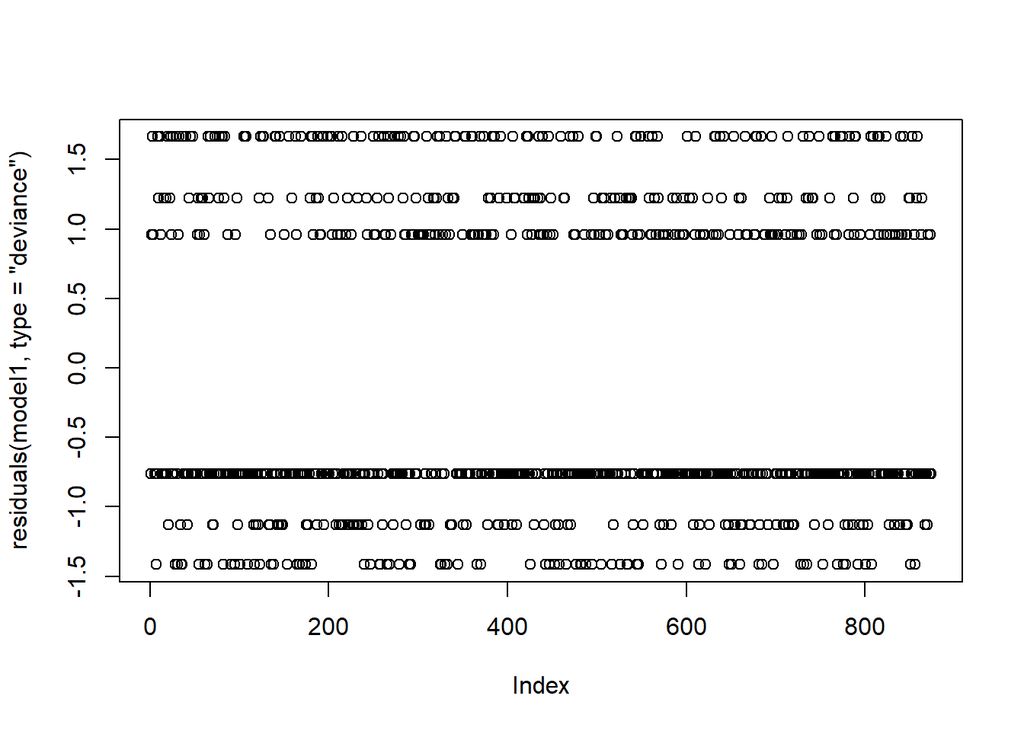

```r
plot(residuals(model1, type = "deviance"))
```

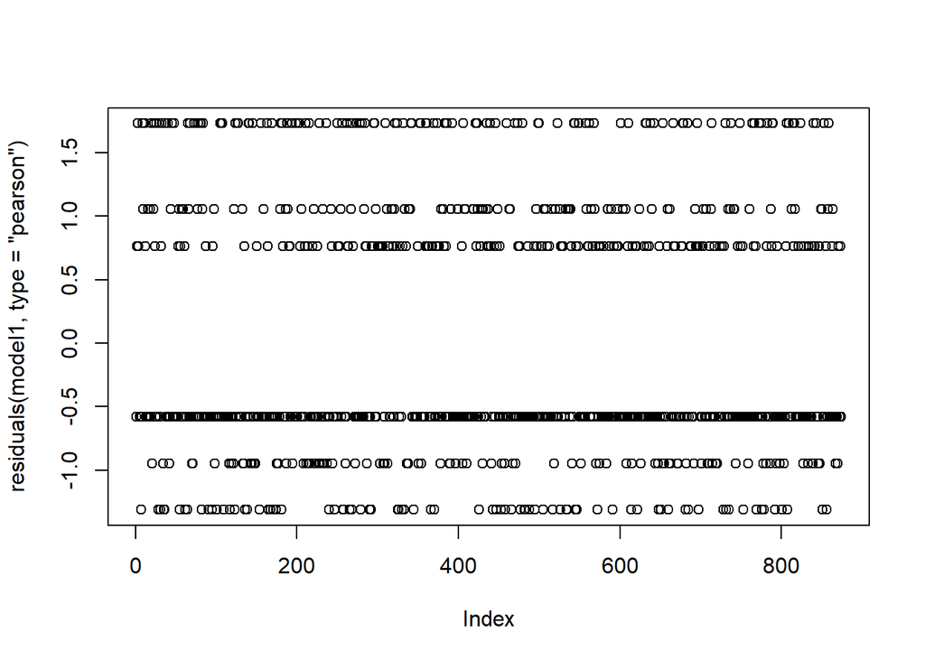

```r
plot(residuals(model1, type = "pearson"))
```

```r
summary(residuals(model1, type = "pearson"))
```

```
##    Min. 1st Qu.  Median    Mean 3rd Qu.    Max.
## -1.3121 -0.5782 -0.5782  0.0000  0.7622  1.7296
```

```r
summary(residuals(model1, type = "deviance"))
```

```
##     Min.  1st Qu.   Median     Mean  3rd Qu.     Max.
## -1.41505 -0.75945 -0.75945 -0.06553  0.95706  1.66385
```

Overall, the model seems to have a good fit to the data.

**(b) 2 pts - Calculate the estimated dispersion parameter for this model. Is this an overdispersed model?**

Dispersion parameter for binomial family taken to be ~1. This is for Pearson resisduals, so deviance residuals are calculated below.

```r
model1_deviance <- deviance(model1)
model1_df_residual <- df.residual(model1)
model1_deviance / model1_df_residual
```

```
## [1] 1.230839
```

The dispersion number is 1.23 for model1, which indicates that it is 23% higher than what would be expected if model were perfectly dispersed. So there is slight overdispersion, but assuming a threshold of 2, this shouldn’t be an issue.

**(c) 2 pts - Using *Survived* as the response variable with *Pclass*, *Sex*, *SibSp*, and *Parch* as the predictors and logit as the link function, fit a logistic regression model and call it** model2**.**

```r
model2 <- glm(Survived ~ Pclass + Sex + SibSp + Parch, data = rawdata, family = binomial)
summary(model2)
```

```
##
## Call:
## glm(formula = Survived ~ Pclass + Sex + SibSp + Parch, family = binomial,
##     data = rawdata)
##
## Coefficients:
##             Estimate Std. Error z value Pr(>|z|)
## (Intercept)  2.24220    0.24694   9.080  < 2e-16 ***
## Pclass2     -0.90206    0.25134  -3.589 0.000332 ***
## Pclass3     -1.74111    0.22018  -7.908 2.62e-15 ***
## Sexmale     -2.71603    0.19666 -13.810  < 2e-16 ***
## SibSp1       0.12680    0.21990   0.577 0.564202
## SibSp2      -0.02141    0.51367  -0.042 0.966753
## SibSp3      -2.03856    0.68440  -2.979 0.002896 **
## SibSp4      -1.37822    0.77500  -1.778 0.075347 .
## Parch1       0.61097    0.27912   2.189 0.028606 *
## Parch2       0.49668    0.35813   1.387 0.165479
## Parch3       0.01535    1.08570   0.014 0.988720
## Parch5      -1.69404    1.16233  -1.457 0.144990
## ---
## Signif. codes:  0 '***' 0.001 '**' 0.01 '*' 0.05 '.' 0.1 ' ' 1
##
## (Dispersion parameter for binomial family taken to be 1)
##
##     Null deviance: 1169.99  on 873  degrees of freedom
## Residual deviance:  791.21  on 862  degrees of freedom
## AIC: 815.21
##
## Number of Fisher Scoring iterations: 4
```

**(d) 3 pts - Using both deviance residuals and Pearson residuals to assess the goodness-of-fit hypothesis test. What do you conclude?**

**Pearson Residuals**

```r
pearson_res <- residuals(model2, type = "pearson")
pearson_chisq <- sum(pearson_res^2)
pchisq(pearson_chisq, df.residual(model2), lower.tail = FALSE)
```

```
## [1] 0.3328549
```

- Null hypothesis: The model fits the data well.
- Fail to reject null hypothesis if p-value > alpha.
- (p-value = 0.33) > (alpha = 0.05)
- Therefore, we fail to reject the null hypothesis, concluding that the model fits the data.

**Deviance Residuals**

```r
pchisq(deviance(model2), df.residual(model2), lower.tail = FALSE)
```

```
## [1] 0.9588858
```

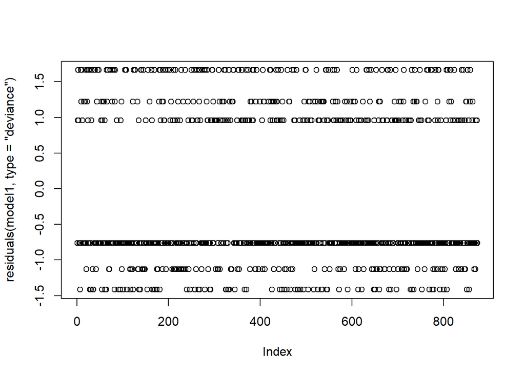

```r
plot(residuals(model1, type = "deviance"))
```

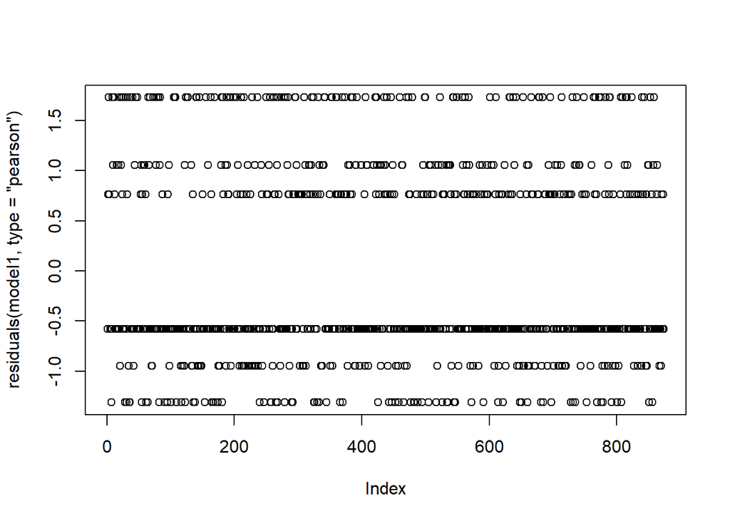

```r
plot(residuals(model1, type = "pearson"))
```

```r
summary(residuals(model1, type = "pearson"))
```

```
##    Min. 1st Qu.  Median    Mean 3rd Qu.    Max.
## -1.3121 -0.5782 -0.5782  0.0000  0.7622  1.7296
```

```r
summary(residuals(model1, type = "deviance"))
```

```
##     Min.  1st Qu.   Median     Mean  3rd Qu.     Max.
## -1.41505 -0.75945 -0.75945 -0.06553  0.95706  1.66385
```

**(e) 3 pts - Calculate the estimated dispersion parameter for this model. Compare model2 with model1 based the p-values of the two tests and the dispersion parameters of the two models. Which model is a better fit?**

```r
anova(model1, model2, test = "Chisq")
```

|  | Resid. Df | Resid. Dev | Df | Deviance | Pr(>Chi) |
| --- | --- | --- | --- | --- | --- |
| 1 | 871 | 1072.0609 | NA | NA | NA |
| 2 | 862 | 791.2057 | 9 | 280.8552 | 2.981246e-55 |

- Null hypothesis: Additional predictors in model2 does not improve the prediction of survival.
- p-value ~ 0 (<2.2e-16), which is less than alpha-level of 0.05.
- Therefore, we reject the null hypothesis, concluding that additional predictors in model2 improve the prediction of survival.

```r
model2_deviance <- deviance(model2)
model2_df_residual <- df.residual(model2)
model2_deviance / model2_df_residual
```

```
## [1] 0.9178721
```

Between these two analyses, model2 is a better fit.

**(f) 2 pts - Please provide two methods that can potentially improve the model fitting.**

- Remove outliers. This will result in better fit since outliers skew results.
- Carefully consider predictors. Are there other predictors not in the data that should be in the model, and vice-versa? Or maybe some could be interactive terms? etc.

# Question 4: Prediction - 7 pts

Suppose there is a passenger with the following characteristics:

1. **Pclass**: 2
2. **Sex**: female
3. **SibSp**: 3
4. **Parch**: 0

**(a) 4 pts - Predict the passenger’s probability of surviving using model1 and model2.**

```r
# compile data
data_prediction <- data.frame(
  Pclass = factor(2, levels = levels(rawdata$Pclass)),
  Sex    = factor("female", levels = c("male", "female")),
  SibSp  = factor(3, levels = levels(rawdata$SibSp)),
  Parch  = factor(0, levels = levels(rawdata$Parch))
)

# predict
prob_model1 <- predict(model1, newdata = data_prediction, type = "response")
prob_model2 <- predict(model2, newdata = data_prediction, type = "response")

# output
paste0("Probability of model1: ", round(prob_model1*100, 2), "%")
```

```
## [1] "Probability of model1: 47.28%"
```

```r
paste0("Probability of model2: ", round(prob_model2*100, 2), "%")
```

```
## [1] "Probability of model2: 33.22%"
```

**(b) 3 pts - Compare your predictions. i.e. which model is more reliable based on the analysis?**

- model1: the predicted probability that a passenger with Pclass = 2 will survive is 47.28%.
- model2: the predicted probability that a passenger with Pclass = 2, Sex = female, SibSp = 3, and Parch = 0 will survive is 33.22%.

Based on the above analysis, model2 (with addtional predictors) is more reliable.

# Part 2: Poisson Regression

# Background

Bicycle crossing counts for East River bridges crossing into Manhattan, New York City, and we want to focus on Manhattan Bridge specifically.

## Data Description

1. **High.Temp…F.**: Numeric.
2. **Low.Temp…F.**: Numeric.
3. **Precipitation**: Numeric.(range from 0-1)
4. **Manhattan.Bridge**: number of bicyclists that cross Manhattan Bridge in a day.

## Setup

You can import the data and set up the problem with the following R code:

```r
# Import the data
casedata <- read.csv("data/bicycle.csv", header=T)

# Remove columns that we do not want
casedata$X <- NULL
casedata$Date <- NULL
casedata$Day <- NULL
casedata$Total <- NULL
casedata$Brooklyn.Bridge <- NULL
casedata$Williamsburg.Bridge <- NULL
casedata$Queensboro.Bridge <- NULL
casedata$Precipitation <- as.numeric(casedata$Precipitation)
names(casedata) = c("Unnamed","High.Temp.F","Low.Temp.F","Precipitation", "Manhattan.Bridge")

# Print head of casedata
head(casedata)
```

|  | Unnamed | High.Temp.F | Low.Temp.F | Precipitation | Manhattan.Bridge |
| --- | --- | --- | --- | --- | --- |
| 1 | 0 | 78.1 | 66.0 | 0.01 | 3126 |
| 2 | 1 | 55.0 | 48.9 | 0.15 | 1646 |
| 3 | 2 | 39.9 | 34.0 | 0.09 | 1232 |
| 4 | 4 | 42.1 | 26.1 | 0.00 | 2617 |
| 5 | 5 | 45.0 | 30.0 | 0.00 | 3329 |
| 6 | 6 | 57.0 | 53.1 | 0.09 | 2581 |

# Question 5: Fitting the Model - 7 pts

Using *Manhattan.Bridge* as the response variable with *High.Temp…F.*, *Low.Temp…F.*, and *Precipitation* as the predictors, fit a poisson regression model and call it **poisson_model**.

**(a) 3 pts - Print the poisson_model summary table. Interpret the estimated coefficient of *Precipitation* with respect to the log expected Manhattan bridge count.**

```r
poisson_model <- glm(
  Manhattan.Bridge ~ High.Temp.F + Low.Temp.F + Precipitation,
  data = casedata,
  family = "poisson"
)

summary(poisson_model)
```

```
##
## Call:
## glm(formula = Manhattan.Bridge ~ High.Temp.F + Low.Temp.F + Precipitation,
##     family = "poisson", data = casedata)
##
## Coefficients:
##                 Estimate Std. Error z value Pr(>|z|)
## (Intercept)    6.9812263  0.0073151  954.36   <2e-16 ***
## High.Temp.F    0.0251439  0.0001857  135.38   <2e-16 ***
## Low.Temp.F    -0.0026123  0.0002129  -12.27   <2e-16 ***
## Precipitation -2.9934837  0.0225137 -132.96   <2e-16 ***
## ---
## Signif. codes:  0 '***' 0.001 '**' 0.01 '*' 0.05 '.' 0.1 ' ' 1
##
## (Dispersion parameter for poisson family taken to be 1)
##
##     Null deviance: 141319  on 195  degrees of freedom
## Residual deviance:  49856  on 192  degrees of freedom
## AIC: 51836
##
## Number of Fisher Scoring iterations: 4
```

**(b) 2 pts - Is the overall regression significant?**

```r
anova(
  glm(Manhattan.Bridge ~ 1, data = casedata, family = "poisson"), # null model
  poisson_model, # full model
  test="Chisq"
)
```

|  | Resid. Df | Resid. Dev | Df | Deviance | Pr(>Chi) |
| --- | --- | --- | --- | --- | --- |
| 1 | 195 | 141318.78 | NA | NA | NA |
| 2 | 192 | 49856.47 | 3 | 91462.31 | 0 |

- Null hypothesis: Additional predictors does not improve the fit.
- Reject null hypothesis if p-value < alpha.
- (p-value = <2.2e-16) < (alpha = 0.05)
- Therefore, we reject the null hypothesis, concluding that the additional predictors improves the fit.

Therefore, the overall regression is statistically significant.

**(c) 2 pts - Perform the Goodness of Fit Test on poisson_model. What do you conclude?**

**Pearson Residuals**

```r
pearson_res <- residuals(poisson_model, type = "pearson")
pearson_chisq <- sum(pearson_res^2)
pchisq(pearson_chisq, df.residual(poisson_model), lower.tail = FALSE)
```

```
## [1] 0
```

- Null hypothesis: The model fits the data well.
- Fail to reject null hypothesis if p-value > alpha.
- (p-value ~ 0) < (alpha = 0.05)
- Therefore, we reject the null hypothesis, concluding that the model does not fit the data.

**Deviance Residuals**

```r
pchisq(deviance(poisson_model), df.residual(poisson_model), lower.tail = FALSE)
```

```
## [1] 0
```

- Null hypothesis: The model fits the data well.
- Fail to reject null hypothesis if p-value > alpha.
- (p-value ~ 0) < (alpha = 0.05)
- Therefore, we reject the null hypothesis, concluding that the model does not fit the data.

Let’s do some more investigating with some plots and stats.

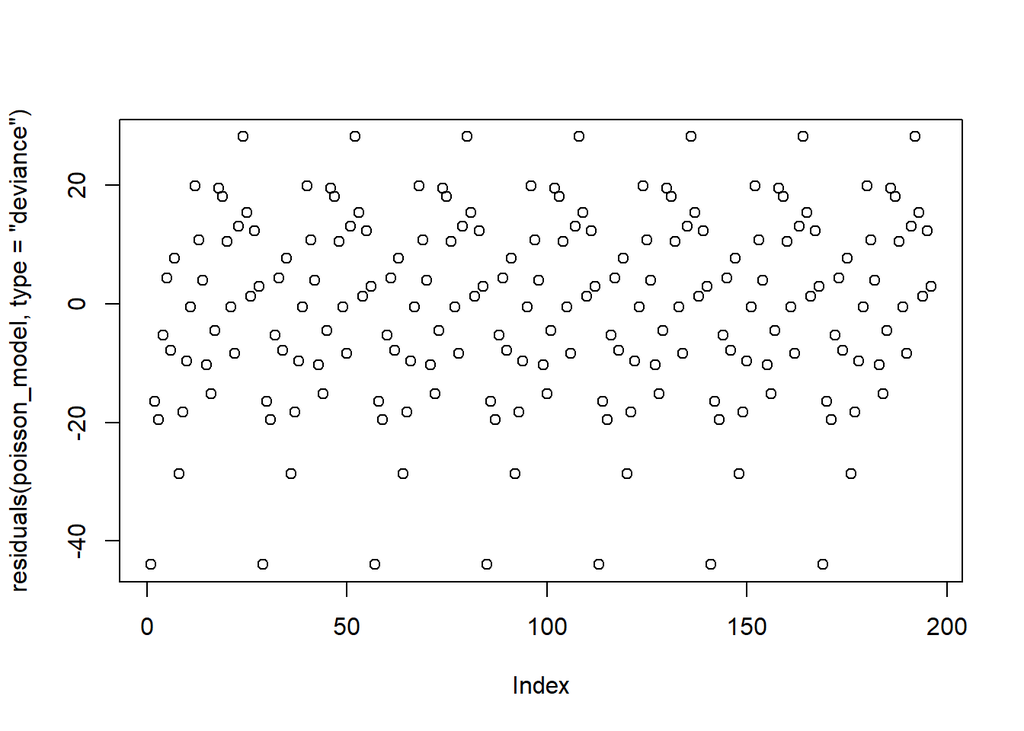

```r
plot(residuals(poisson_model, type = "deviance"))
```

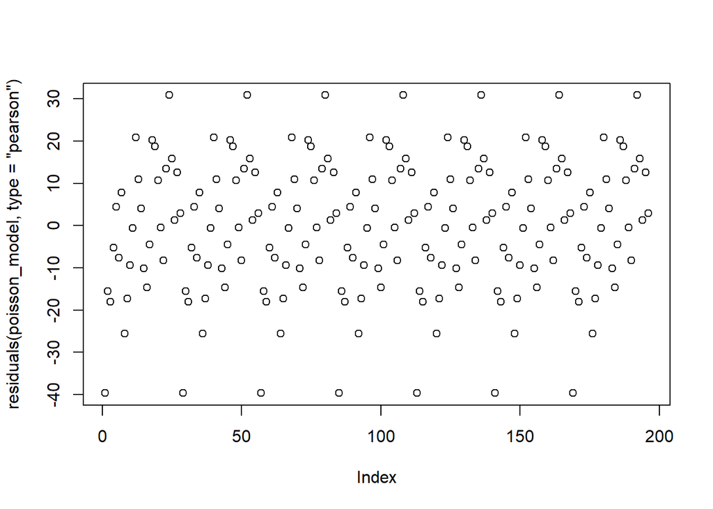

```r
plot(residuals(poisson_model, type = "pearson"))
```

```r
summary(residuals(poisson_model, type = "pearson"))
```

```
##      Min.   1st Qu.    Median      Mean   3rd Qu.      Max.
## -39.65124  -9.55089   0.38740  -0.07467  11.42149  30.88084
```

```r
summary(residuals(poisson_model, type = "deviance"))
```

```
##     Min.  1st Qu.   Median     Mean  3rd Qu.     Max.
## -43.9402  -9.7903   0.3850  -0.7813  11.1066  28.1322
```

Ideally for a good goodness of fit, residuals should be randomly scattered around zero without a clear pattern. This does not appear to be the case in both plots; it appears there is a repeating pattern per every ~25 indexes with repeating one-off lows and highs. Also, the averages deviate from zero.

The graphs confirm that the model does not fit the data

# Question 6: Outlier detection - 13 pts

**(a) 2 pts - Create the Q-Q plot of the residuals. Are there any outliers based on the plot?**

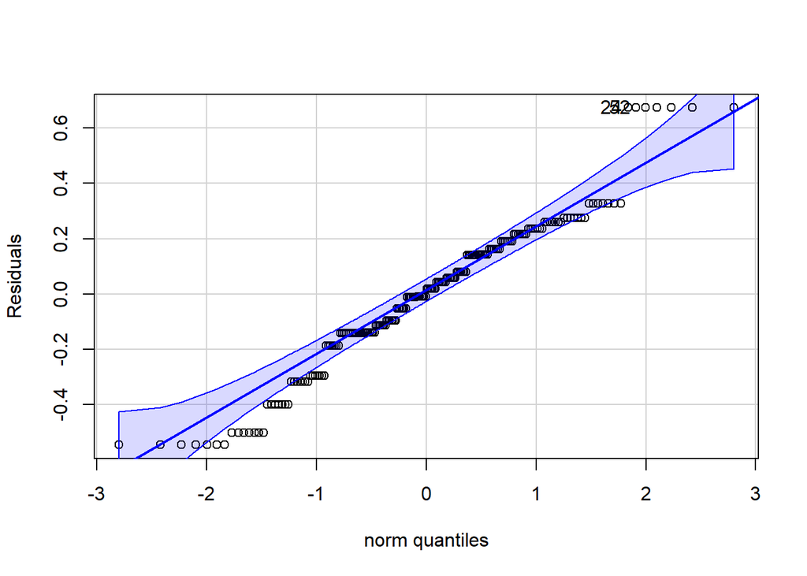

```
## [1] 24 52
```

```r
qqPlot(poisson_model$residuals, ylab = "Residuals")
```

Yes, there appears to be outliers, especially at the upper tail.

**(b) 4 pts - Using the Cook’s Distance with threshold = 1 to get the number of outliers. Remove the outliers from the dataset, and create model3 with the new dataset.**

```r
# identifying outliers
cooks_distance <- cooks.distance(poisson_model)
outliers <- which(cooks_distance > 1)

# removing outliers
data_no_outliers <- casedata[-outliers, ]

# new model without outliers
model3 <- glm(
  Manhattan.Bridge ~ High.Temp.F + Low.Temp.F + Precipitation,
  family = "poisson",
  data = data_no_outliers
)

summary(model3)
```

```
##
## Call:
## glm(formula = Manhattan.Bridge ~ High.Temp.F + Low.Temp.F + Precipitation,
##     family = "poisson", data = data_no_outliers)
##
## Coefficients:
##                 Estimate Std. Error z value Pr(>|z|)
## (Intercept)    6.9658836  0.0101762  684.53   <2e-16 ***
## High.Temp.F    0.0178091  0.0002346   75.93   <2e-16 ***
## Low.Temp.F     0.0089594  0.0003398   26.37   <2e-16 ***
## Precipitation -4.0817244  0.0341993 -119.35   <2e-16 ***
## ---
## Signif. codes:  0 '***' 0.001 '**' 0.01 '*' 0.05 '.' 0.1 ' ' 1
##
## (Dispersion parameter for poisson family taken to be 1)
##
##     Null deviance: 56606.7  on 132  degrees of freedom
## Residual deviance:  8387.6  on 129  degrees of freedom
## AIC: 9751.8
##
## Number of Fisher Scoring iterations: 4
```

**(c) 4 pts - Perform the deviance residual test to check the goodness-of-fit of model3. What do you conclude? Discuss the appropriateness of using Cook’s Distance for poisson regression.**

```r
pchisq(deviance(model3), df.residual(model3), lower.tail = FALSE)
```

```
## [1] 0
```

```r
# verify for same results: code from lecture
with(model3, cbind(
  res.deviance = deviance,
  df = df.residual,
  p = 1- pchisq(deviance, df.residual)
))
```

```
##      res.deviance  df p
## [1,]     8387.554 129 0
```

```r
# both methods give 0
```

- Null hypothesis: The model fits the data well.
- Fail to reject null hypothesis if p-value > alpha.
- (p-value ~ 0) < (alpha = 0.05)
- Therefore, we reject the null hypothesis, concluding that the model does not fit the data.

Also note that Cook’s Distance assumes a linear predictor scale, in contrast to a Poisson distribution which assumes a count scale. It doesn’t quite translate.

**(d) 3 pts - Is there another approach to identify outliers? What assumptions we need to make for that approach? What is the number of outliers found using that approach?**

Another approach would be to look at deviance residuals, which has the following assumptions:

- Poisson distribution
- No overdispersion
- Goodness of fit (Deviance coming from a N(0,1))

```r
deviance_resid <- residuals(poisson_model, type = "deviance")
outliers <- which(abs(deviance_resid) > qnorm(.99995))
length(outliers)
```

```
## [1] 168
```

Using this approach, there are 168 outliers identified.